# Untitled

## Background Information

The magnitude and depth of influence of edge effects are dictated largely by edge permeability and edge contrast with adjoining patches (Cadenosso et al. 2003). Less understood is how edge effects are impacted by the interaction of nearby edges. Edge interactions show promise in explaining landscape-level variations in species distributions due to regional changes in spatial complexity (e.g., number of interacting edges)(Fletcher 2005).

Using data obtained on populations of *Heliconia acuminata* located within the experimentally fragmented rainforest of the BDFFP, we will attempt to quantify the depth and magnitude of the edge effects for 1-ha fragments using vocabulary consistent with the conceptual framework outlined by Porensky and Young (2013). This population data provides us with a unique opportunity to determine the demographic consequences of a population that is subjected to edge interaction. Specifically, if there are edge effects, then the annual growth rates of *H. acuminata*, abundance of *H. acuminata*, and survivorship of *H. acuminata* will be significantly lower in areas of fragments where a strengthening edge effect is observed because of edge interaction. Another question to answer would be if plants experiencing edge effects demonstrate greater year-to-year variance in their measured response variables. Quantifying variance on important demographic parameters could be relevant to smaller populations, as increased variance in vital rates of a small population can dramatically increase extinction risk.

## Question asked

Are there edge-dependent effects impacting survival, flowering, and size of *H. acuminata* within 1-ha forest fragments in the BDFFP?

Can depth of influence (DOI) of any observed edge effects be determined?

Is year-to-year variation in vital rates significant?

## General Methods

I used generalized linear mixed models (GLMMs) to perform logistic regression on the categorical, binary variables of survival and flowering respectively. I also used a linear mixed model to perform regression on the continuous variable log_size. Models were created using the R package lme4. Models were fit using a step-wise elimination procedure where significance of random effects and fixed effects was determined through a series of likelihood-ratio tests. Signficance of interaction terms was determined using R package car to perform a Type II Wald Chi-squared test. 84% Confidence intervals were fit around predicted model outputs and compared against baseline values from continuous forest habitat to identify an edge effect’s DOI.

## Preliminary Results

I. Is there a edge effect on survival in *H. acuminata*?

I looked at distance as a predictor for survival using the center point of the 10mx10m sub plots. I started by first determining if year was a significant random effect for survival by using the likelihood ratio test. I found that year was not a significant random effect and distance to nearest edge was also not a significant predictor of survival.

```
## Data: dist_10m
## Models:
## surv.m2: surv ~ log_size_prev + dist_near + bdffp_reserve_no
## surv.m1: surv ~ log_size_prev + dist_near + bdffp_reserve_no + (1 | year)
##         npar    AIC    BIC  logLik deviance  Chisq Df Pr(>Chisq)
## surv.m2    5 2687.4 2721.8 -1338.7   2677.4
## surv.m1    6 2686.3 2727.7 -1337.2   2674.3 3.0255  1    0.08197 .
## ---
## Signif. codes:  0 '***' 0.001 '**' 0.01 '*' 0.05 '.' 0.1 ' ' 1
```

```
## Analysis of Deviance Table
##
## Model 1: surv ~ log_size_prev + bdffp_reserve_no
## Model 2: surv ~ log_size_prev + dist_near + bdffp_reserve_no
##   Resid. Df Resid. Dev Df Deviance Pr(>Chi)
## 1      7274     2679.0
## 2      7273     2677.4  1   1.6668   0.1967
```

```
## # R2 for Logistic Regression
##   Tjur's R2: 0.060
```

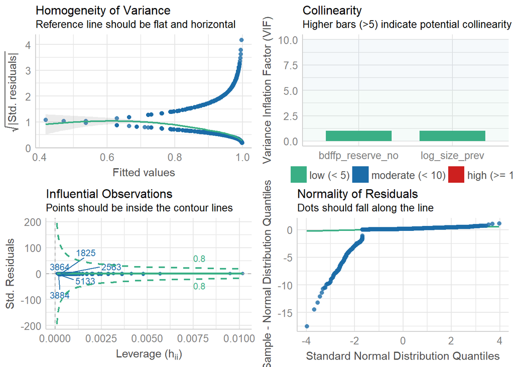

|  | surv |  |  |
| --- | --- | --- | --- |
| Predictors | Odds Ratios | CI | p |
| (Intercept) | 0.61 | 0.43 – 0.88 | **0.008** |
| log_size_prev | 2.52 | 2.26 – 2.81 | **<0.001** |
| bdffp_reserve_no [2107] | 1.45 | 1.12 – 1.89 | **0.005** |
| bdffp_reserve_no [3114] | 1.17 | 0.92 – 1.51 | 0.207 |
| Observations | 7278 |  |  |
| R<sup>2</sup> Tjur | 0.060 |  |  |

I repeated this analysis using a separate data frame containing distances to edge that were accurate to roughly 0.1m. At a finer scale, distance was a significant predictor for survival (p = 0.007) and year was found to be a significant random effect using Likelihood ratio tests to compare a mixed effect model to a generalized linear model with fixed covariates fit through a single intercept. In terms of determining predictive power of the selected model, I used the Hmisc package and rcorr.cens function to calculate Somer’s Dxy and C-value associated with the area under the receiver operating characteristic (ROC) curve area. Values obtained were above 0.8, which indicates real predictive power from the selected model.

```
## Data: dist_fine
## Models:
## surv.fine.m2: surv ~ log_size_prev + distance_to_nearest_edge + bdffp_reserve_no
## surv.fine.m1: surv ~ log_size_prev + distance_to_nearest_edge + bdffp_reserve_no + (1 | year)
##              npar    AIC    BIC  logLik deviance  Chisq Df Pr(>Chisq)
## surv.fine.m2    5 328.53 360.46 -159.26   318.53
## surv.fine.m1    6 243.37 281.68 -115.69   231.37 87.159  1  < 2.2e-16 ***
## ---
## Signif. codes:  0 '***' 0.001 '**' 0.01 '*' 0.05 '.' 0.1 ' ' 1
```

```
## Data: dist_fine
## Models:
## surv.fine.m3: surv ~ log_size_prev + bdffp_reserve_no + (1 | year)
## surv.fine.m1: surv ~ log_size_prev + distance_to_nearest_edge + bdffp_reserve_no + (1 | year)
##              npar    AIC    BIC  logLik deviance Chisq Df Pr(>Chisq)
## surv.fine.m3    5 248.62 280.54 -119.31   238.62
## surv.fine.m1    6 243.37 281.68 -115.69   231.37 7.245  1    0.00711 **
## ---
## Signif. codes:  0 '***' 0.001 '**' 0.01 '*' 0.05 '.' 0.1 ' ' 1
```

```
## Data: dist_fine
## Models:
## surv.fine.m1: surv ~ log_size_prev + distance_to_nearest_edge + bdffp_reserve_no + (1 | year)
## surv.fine.m4: surv ~ log_size_prev * bdffp_reserve_no * distance_to_nearest_edge + (1 | year)
##              npar    AIC    BIC  logLik deviance  Chisq Df Pr(>Chisq)
## surv.fine.m1    6 243.37 281.68 -115.69   231.37
## surv.fine.m4   13 250.26 333.27 -112.13   224.26 7.1069  7     0.4178
```

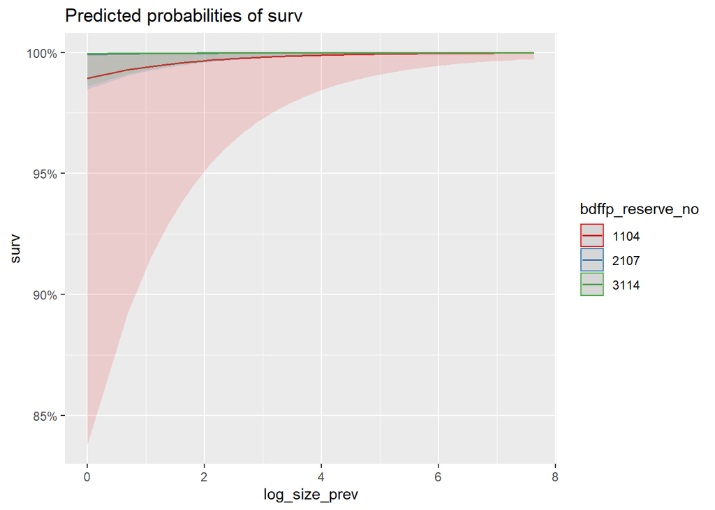

|  | surv |  |  |
| --- | --- | --- | --- |
| Predictors | Odds Ratios | CI | p |
| (Intercept) | 38.97 | 2.03 – 746.75 | **0.015** |
| log_size_prev | 1.78 | 1.30 – 2.44 | **<0.001** |
| distance_to_nearest_edge | 1.05 | 1.01 – 1.08 | **0.009** |
| bdffp_reserve_no [2107] | 15.67 | 4.44 – 55.27 | **<0.001** |
| bdffp_reserve_no [3114] | 18.96 | 4.27 – 84.20 | **<0.001** |
| Random Effects |  |  |  |
| σ<sup>2</sup> | 3.29 |  |  |
| τ<sub>00</sub> <sub>year</sub> | 6.17 |  |  |
| ICC | 0.65 |  |  |
| N <sub>year</sub> | 11 |  |  |
| Observations | 4383 |  |  |
| Marginal R<sup>2</sup> / Conditional R<sup>2</sup> | 0.175 / 0.713 |  |  |

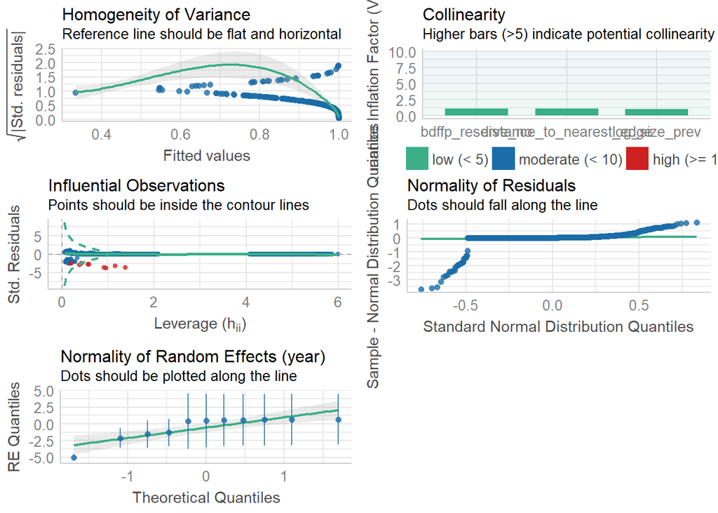

```
##        C Index            Dxy           S.D.              n        missing
##   9.651445e-01   9.302890e-01   2.239549e-02   4.383000e+03   0.000000e+00
##     uncensored Relevant Pairs     Concordant      Uncertain
##   4.383000e+03   2.784640e+05   2.687580e+05   0.000000e+00
```

Since I detected an edge effect for survival, what is its depth of influence (DOI)?

The figure below shows that for the average sized *H. acuminata*, plots 2107 and 3114 survival rates were much higher than CF habitat, while plot 1104 had comparable survival probabilities with CF 9m away from the nearest edge, thereafter the plot outperformed CF survival probability. Overall, DOI was impossible to determine due to immediate overlap in probabilities between the two habitat types. I’m curious why CF has a lower calculated survival probability compared to these fragments. One explanation may be that CF have more old plants on average than forest fragment plots, which could explain the discrepancy in the predicted vital rates. Either that or the functional form of the model is overestimating survival in forest fragments.

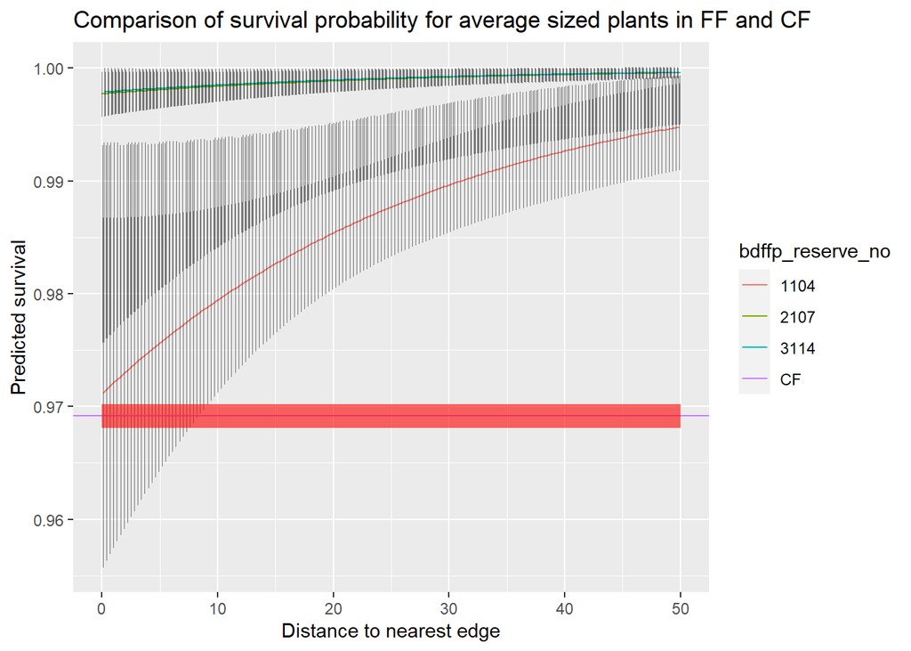

I’m particularly curious about the aforementioned plots 2107 and 3114, which show remarkably high survival probabilities, yet my data visualization of the population decline in forest fragments over the years seems to contradict these predicted survival probabilities. Below are two figures showing total population and population broken down by bdffp_reserve_no temporal trajectories.

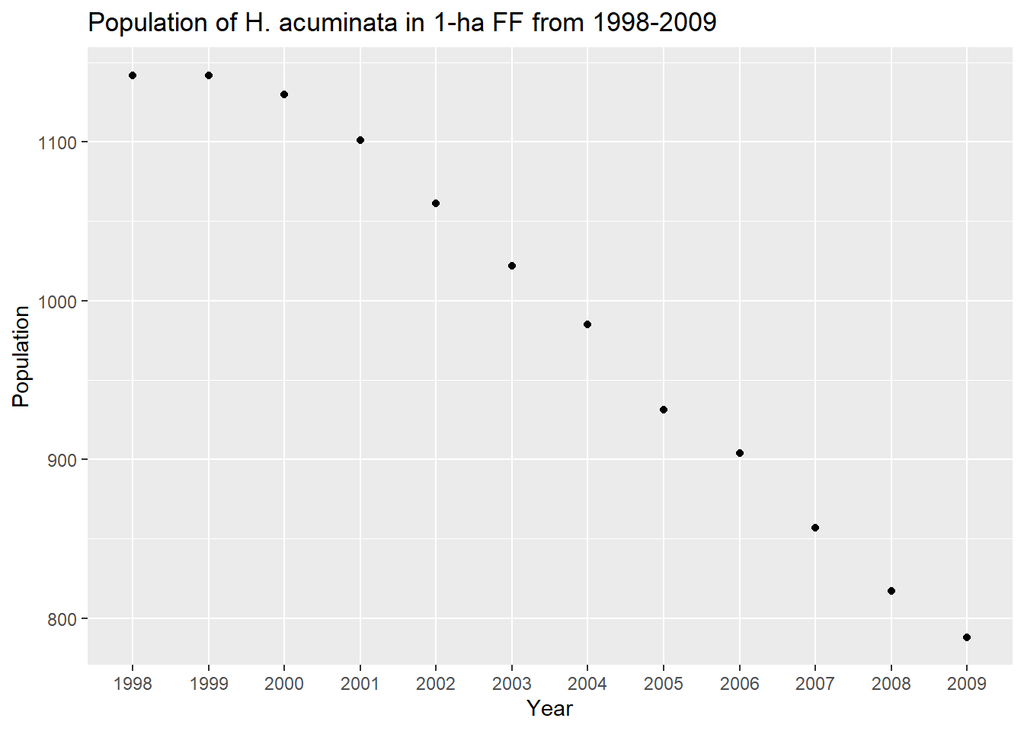

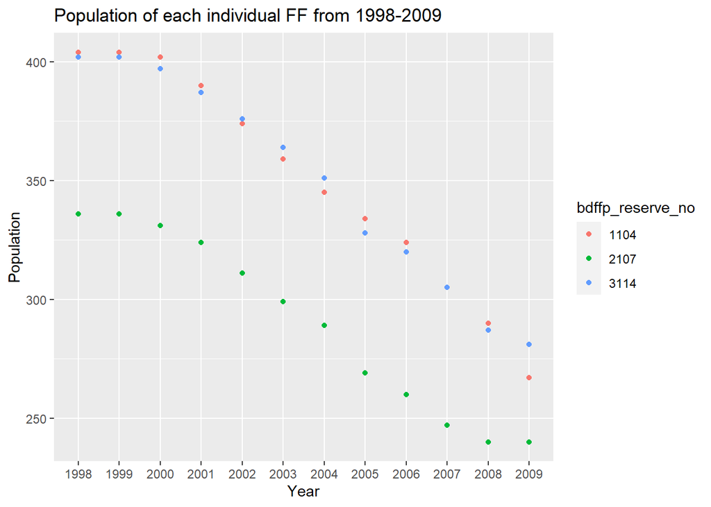

```
##       0%      25%      50%      75%     100%
## 0.000000 3.258097 4.248495 5.010635 7.643962
```

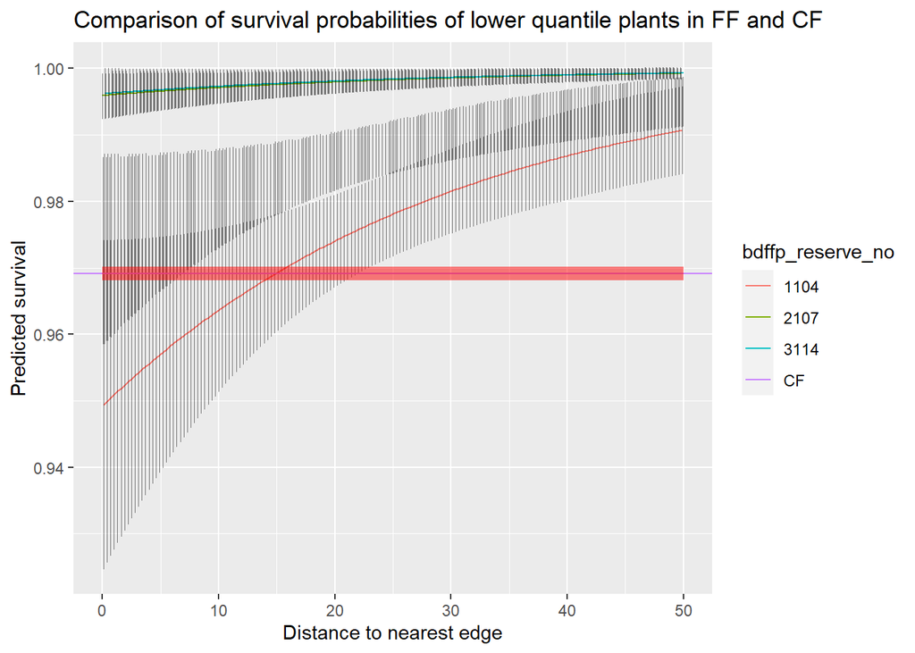

Comparison of quantiles in log_size_prev in two habitat types: (1) FF (2) CF Found FF had larger sized plants as threshold value for 25% quantile, may explain why their survival probabilities were higher than expected.

```
##       0%      25%      50%      75%     100%
## 0.000000 3.258097 4.248495 5.010635 7.643962
```

```
##       0%      25%      50%      75%     100%
## 0.000000 3.044522 4.382027 5.257495 8.018296
```

2. Is there an edge effect on flowering probability in *H. acuminata*?

I found that year is a relevant random effect, though df comparison may be questionable, as there is debate on how random effects should contribute to degrees of freedom, also based on hierarchy of experimental design. There was a significant interaction term log_size_prev*bdffp_reserve_no and distance_near was not a significant predictor of flowering for 10m data set. Model diagnostics show major collinearity issues for the best fit model including the interaction term, which may make assessing the value of individual predictors very difficult, so the second best model was selected.

```
## Data: dist_10m
## Models:
## flwr.m2: flwr ~ log_size_prev + dist_near + bdffp_reserve_no
## flwr.m1: flwr ~ log_size_prev + flwr_prev + dist_near + bdffp_reserve_no + (1 | year)
##         npar    AIC  BIC  logLik deviance  Chisq Df Pr(>Chisq)
## flwr.m2    5 1266.0 1300 -627.98   1256.0
## flwr.m1    7 1188.3 1236 -587.16   1174.3 81.639  2  < 2.2e-16 ***
## ---
## Signif. codes:  0 '***' 0.001 '**' 0.01 '*' 0.05 '.' 0.1 ' ' 1
```

```
## Data: dist_10m
## Models:
## flwr.m1: flwr ~ log_size_prev + flwr_prev + dist_near + bdffp_reserve_no + (1 | year)
## flwr.m3: flwr ~ log_size_prev * dist_near * bdffp_reserve_no + flwr_prev + (1 | year)
##         npar    AIC    BIC  logLik deviance  Chisq Df Pr(>Chisq)
## flwr.m1    7 1188.3 1236.0 -587.16   1174.3
## flwr.m3   14 1185.3 1280.7 -578.65   1157.3 17.027  7    0.01722 *
## ---
## Signif. codes:  0 '***' 0.001 '**' 0.01 '*' 0.05 '.' 0.1 ' ' 1
```

```
## Analysis of Deviance Table (Type II Wald chisquare tests)
##
## Response: flwr
##                                             Chisq Df Pr(>Chisq)
## log_size_prev                            224.5957  1  < 2.2e-16 ***
## dist_near                                  1.2835  1  0.2572460
## bdffp_reserve_no                          17.3440  2  0.0001713 ***
## flwr_prev                                 18.6593  1  1.563e-05 ***
## log_size_prev:dist_near                    0.4753  1  0.4905437
## log_size_prev:bdffp_reserve_no             7.9883  2  0.0184234 *
## dist_near:bdffp_reserve_no                 0.7033  2  0.7035263
## log_size_prev:dist_near:bdffp_reserve_no   3.6668  2  0.1598662
## ---
## Signif. codes:  0 '***' 0.001 '**' 0.01 '*' 0.05 '.' 0.1 ' ' 1
```

```
## Data: dist_10m
## Models:
## flwr.m4: flwr ~ log_size_prev * bdffp_reserve_no + dist_near + flwr_prev + (1 | year)
## flwr.m3: flwr ~ log_size_prev * dist_near * bdffp_reserve_no + flwr_prev + (1 | year)
##         npar    AIC    BIC  logLik deviance  Chisq Df Pr(>Chisq)
## flwr.m4    9 1180.2 1241.5 -581.09   1162.2
## flwr.m3   14 1185.3 1280.7 -578.65   1157.3 4.8959  5     0.4287
```

```
## Data: dist_10m
## Models:
## flwr.m5: flwr ~ log_size_prev * bdffp_reserve_no + flwr_prev + (1 | year)
## flwr.m4: flwr ~ log_size_prev * bdffp_reserve_no + dist_near + flwr_prev + (1 | year)
##         npar    AIC    BIC  logLik deviance  Chisq Df Pr(>Chisq)
## flwr.m5    8 1179.7 1234.2 -581.84   1163.7
## flwr.m4    9 1180.2 1241.5 -581.09   1162.2 1.4865  1     0.2228
```

```
## Data: dist_10m
## Models:
## flwr.m6: flwr ~ log_size_prev * bdffp_reserve_no + (1 | year)
## flwr.m5: flwr ~ log_size_prev * bdffp_reserve_no + flwr_prev + (1 | year)
##         npar    AIC    BIC  logLik deviance  Chisq Df Pr(>Chisq)
## flwr.m6    7 1196.6 1244.3 -591.32   1182.6
## flwr.m5    8 1179.7 1234.2 -581.84   1163.7 18.967  1   1.33e-05 ***
## ---
## Signif. codes:  0 '***' 0.001 '**' 0.01 '*' 0.05 '.' 0.1 ' ' 1
```

```
## Data: dist_10m
## Models:
## flwr.m7: flwr ~ log_size_prev + bdffp_reserve_no + flwr_prev + (1 | year)
## flwr.m5: flwr ~ log_size_prev * bdffp_reserve_no + flwr_prev + (1 | year)
##         npar    AIC    BIC  logLik deviance  Chisq Df Pr(>Chisq)
## flwr.m7    6 1187.7 1228.6 -587.86   1175.7
## flwr.m5    8 1179.7 1234.2 -581.84   1163.7 12.036  2   0.002434 **
## ---
## Signif. codes:  0 '***' 0.001 '**' 0.01 '*' 0.05 '.' 0.1 ' ' 1
```

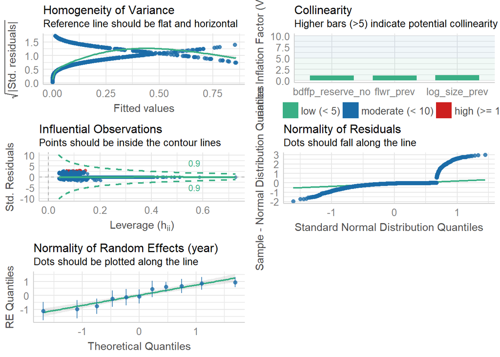

|  | flwr |  |  |
| --- | --- | --- | --- |
| Predictors | Odds Ratios | CI | p |
| (Intercept) | 0.00 | 0.00 – 0.00 | **<0.001** |
| log_size_prev | 8.73 | 6.63 – 11.51 | **<0.001** |
| bdffp_reserve_no [2107] | 1.36 | 0.92 – 2.00 | 0.122 |
| bdffp_reserve_no [3114] | 0.54 | 0.36 – 0.83 | **0.005** |
| flwr_prev [1] | 2.77 | 1.84 – 4.19 | **<0.001** |
| Random Effects |  |  |  |
| σ<sup>2</sup> | 3.29 |  |  |
| τ<sub>00</sub> <sub>year</sub> | 0.59 |  |  |
| ICC | 0.15 |  |  |
| N <sub>year</sub> | 11 |  |  |
| Observations | 6738 |  |  |
| Marginal R<sup>2</sup> / Conditional R<sup>2</sup> | 0.619 / 0.677 |  |  |

Now to repeat this analysis using finer distances. We found that year was a significant random effect and distance to nearest edge was also a significant predictor(χ2 = 4.1382, df=1, p= 0.041) for flowering probability. Due to there being outliers present and the p value being close to the cutoff, this outcome may be questionable, especially since the upper confidence interval boundary for this predictor is an odds ratio of 1. Calculated Somer’s Dxy and C-values obtained indicate real predictive power from the selected model.

```
## Data: dist_fine
## Models:
## flwr.fine.m2: flwr ~ log_size_prev + flwr_prev + distance_to_nearest_edge + bdffp_reserve_no
## flwr.fine.m1: flwr ~ log_size_prev + flwr_prev + distance_to_nearest_edge + bdffp_reserve_no + (1 | year)
##              npar    AIC    BIC  logLik deviance Chisq Df Pr(>Chisq)
## flwr.fine.m2    6 891.75 929.92 -439.87   879.75
## flwr.fine.m1    7 853.40 897.93 -419.70   839.40 40.35  1  2.123e-10 ***
## ---
## Signif. codes:  0 '***' 0.001 '**' 0.01 '*' 0.05 '.' 0.1 ' ' 1
```

```
## Data: dist_fine
## Models:
## flwr.fine.m3: flwr ~ log_size_prev + flwr_prev + bdffp_reserve_no + (1 | year)
## flwr.fine.m1: flwr ~ log_size_prev + flwr_prev + distance_to_nearest_edge + bdffp_reserve_no + (1 | year)
##              npar    AIC    BIC  logLik deviance  Chisq Df Pr(>Chisq)
## flwr.fine.m3    6 855.53 893.70 -421.77   843.53
## flwr.fine.m1    7 853.40 897.93 -419.70   839.40 4.1382  1    0.04193 *
## ---
## Signif. codes:  0 '***' 0.001 '**' 0.01 '*' 0.05 '.' 0.1 ' ' 1
```

```
## Data: dist_fine
## Models:
## flwr.fine.m4: flwr ~ log_size_prev + flwr_prev + distance_to_nearest_edge + (1 | year)
## flwr.fine.m1: flwr ~ log_size_prev + flwr_prev + distance_to_nearest_edge + bdffp_reserve_no + (1 | year)
##              npar    AIC    BIC  logLik deviance  Chisq Df Pr(>Chisq)
## flwr.fine.m4    5 873.88 905.69 -431.94   863.88
## flwr.fine.m1    7 853.40 897.93 -419.70   839.40 24.483  2  4.827e-06 ***
## ---
## Signif. codes:  0 '***' 0.001 '**' 0.01 '*' 0.05 '.' 0.1 ' ' 1
```

```
## Data: dist_fine
## Models:
## flwr.fine.m5: flwr ~ log_size_prev + distance_to_nearest_edge + bdffp_reserve_no + (1 | year)
## flwr.fine.m1: flwr ~ log_size_prev + flwr_prev + distance_to_nearest_edge + bdffp_reserve_no + (1 | year)
##              npar    AIC    BIC  logLik deviance  Chisq Df Pr(>Chisq)
## flwr.fine.m5    6 859.65 897.82 -423.82   847.65
## flwr.fine.m1    7 853.40 897.93 -419.70   839.40 8.2506  1   0.004074 **
## ---
## Signif. codes:  0 '***' 0.001 '**' 0.01 '*' 0.05 '.' 0.1 ' ' 1
```

```
## Generalized linear mixed model fit by maximum likelihood (Laplace
##   Approximation) [glmerMod]
##  Family: binomial  ( logit )
## Formula: flwr ~ log_size_prev + flwr_prev + distance_to_nearest_edge +
##     bdffp_reserve_no + (1 | year)
##    Data: dist_fine
##
##      AIC      BIC   logLik deviance df.resid
##    853.4    897.9   -419.7    839.4     4273
##
## Scaled residuals:
##     Min      1Q  Median      3Q     Max
## -3.1875 -0.1405 -0.0544 -0.0161  9.6369
##
## Random effects:
##  Groups Name        Variance Std.Dev.
##  year   (Intercept) 0.5953   0.7716
## Number of obs: 4280, groups:  year, 11
##
## Fixed effects:
##                            Estimate Std. Error z value Pr(>|z|)
## (Intercept)              -14.893111   1.041951 -14.293  < 2e-16 ***
## log_size_prev              2.337068   0.178535  13.090  < 2e-16 ***
## flwr_prev1                 0.730154   0.247976   2.944  0.00324 **
## distance_to_nearest_edge  -0.017510   0.008592  -2.038  0.04155 *
## bdffp_reserve_no2107       0.164606   0.240128   0.685  0.49303
## bdffp_reserve_no3114      -1.158935   0.295388  -3.923 8.73e-05 ***
## ---
## Signif. codes:  0 '***' 0.001 '**' 0.01 '*' 0.05 '.' 0.1 ' ' 1
##
## Correlation of Fixed Effects:
##             (Intr) lg_sz_ flwr_1 dst___ b__210
## log_siz_prv -0.938
## flwr_prev1   0.213 -0.298
## dstnc_t_nr_ -0.118 -0.107  0.074
## bdffp__2107 -0.382  0.228  0.004  0.391
## bdffp__3114 -0.040 -0.106  0.091  0.349  0.386
```

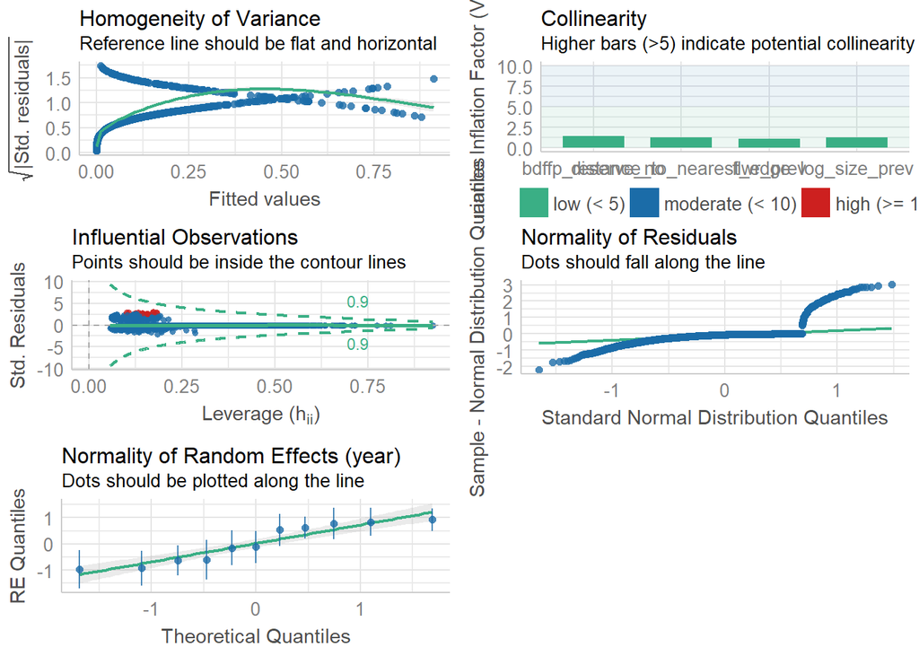

|  | flwr |  |  |
| --- | --- | --- | --- |
| Predictors | Odds Ratios | CI | p |
| (Intercept) | 0.00 | 0.00 – 0.00 | **<0.001** |
| log_size_prev | 10.35 | 7.29 – 14.69 | **<0.001** |
| flwr_prev [1] | 2.08 | 1.28 – 3.37 | **0.003** |
| distance_to_nearest_edge | 0.98 | 0.97 – 1.00 | **0.042** |
| bdffp_reserve_no [2107] | 1.18 | 0.74 – 1.89 | 0.493 |
| bdffp_reserve_no [3114] | 0.31 | 0.18 – 0.56 | **<0.001** |
| Random Effects |  |  |  |
| σ<sup>2</sup> | 3.29 |  |  |
| τ<sub>00</sub> <sub>year</sub> | 0.60 |  |  |
| ICC | 0.15 |  |  |
| N <sub>year</sub> | 11 |  |  |
| Observations | 4280 |  |  |
| Marginal R<sup>2</sup> / Conditional R<sup>2</sup> | 0.650 / 0.704 |  |  |

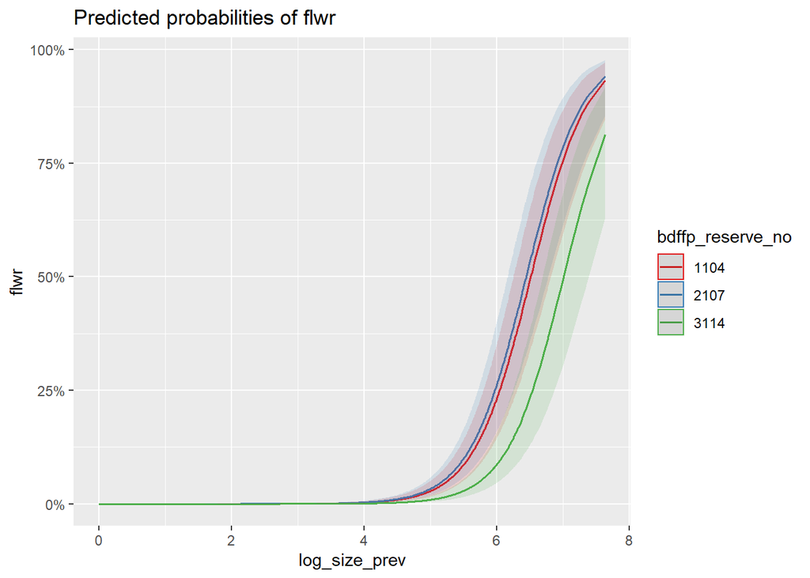

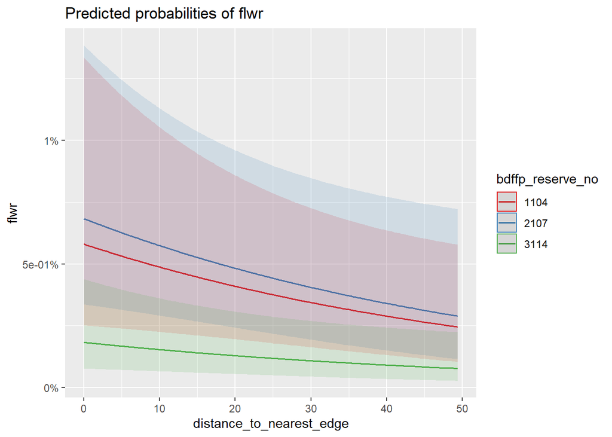

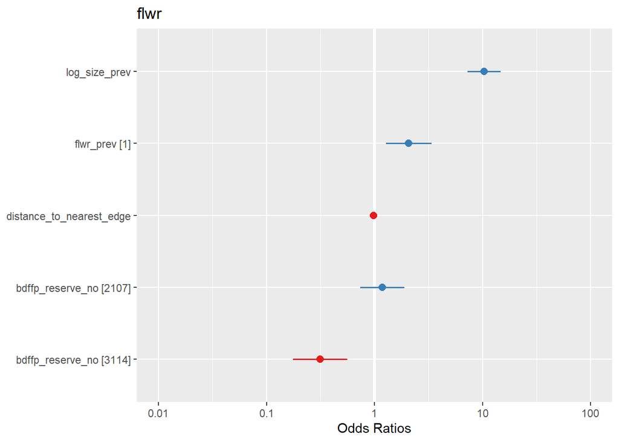

```
##        C Index            Dxy           S.D.              n        missing
##   9.404005e-01   8.808009e-01   1.234347e-02   4.280000e+03   0.000000e+00
##     uncensored Relevant Pairs     Concordant      Uncertain
##   4.280000e+03   1.262862e+06   1.187596e+06   0.000000e+00
```

What is the DOI of the effect?

Taking into account the 84% CIs around the predicted estimates, a depth of influence was impossible to determine, as there was immediate overlap in the probabilities.

```
##
## Call:
## glm(formula = flwr ~ log_size_prev + flwr_prev + distance_to_nearest_edge +
##     bdffp_reserve_no, family = binomial, data = dist_fine)
##
## Deviance Residuals:
##      Min        1Q    Median        3Q       Max
## -2.32892  -0.21373  -0.09516  -0.03165   3.06500
##
## Coefficients:
##                            Estimate Std. Error z value Pr(>|z|)
## (Intercept)              -13.662422   0.932659 -14.649  < 2e-16 ***
## log_size_prev              2.126475   0.162966  13.049  < 2e-16 ***
## flwr_prev1                 0.735056   0.232762   3.158 0.001589 **
## distance_to_nearest_edge  -0.015569   0.008357  -1.863 0.062467 .
## bdffp_reserve_no2107       0.103097   0.234938   0.439 0.660787
## bdffp_reserve_no3114      -0.972036   0.282549  -3.440 0.000581 ***
## ---
## Signif. codes:  0 '***' 0.001 '**' 0.01 '*' 0.05 '.' 0.1 ' ' 1
##
## (Dispersion parameter for binomial family taken to be 1)
##
##     Null deviance: 1319.83  on 4279  degrees of freedom
## Residual deviance:  879.75  on 4274  degrees of freedom
##   (2659 observations deleted due to missingness)
## AIC: 891.75
##
## Number of Fisher Scoring iterations: 8
```

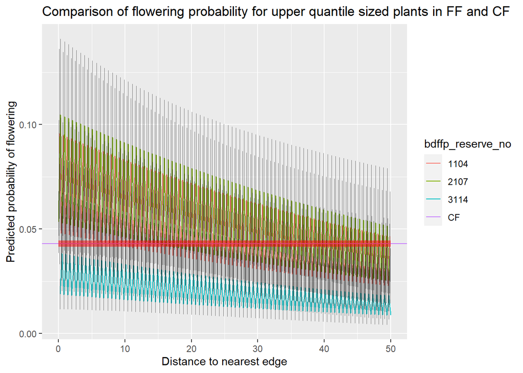

3. Is there an edge effect on log_size of *H. acuminata*?

I found that distance to nearest edge was not a significant predictor for log_size of plants using distances at 10m intervals. Year was an important random effect that improved model fit.(see conditional versus marginal R2 below). When model fitting, a significant interaction term was found log_size_prev*bdffp_reserve_no, but this introduced large collinearity issues, so the second best-fit model was selected.

```r
log_size.m1 <- lmer(log_size~log_size_prev*bdffp_reserve_no*dist_near+(1|year),
                    data=dist_10m)

log_size.m2 <- lm(log_size~log_size_prev*bdffp_reserve_no*dist_near,data=dist_10m)

anova(log_size.m1,log_size.m2,test="LRT")
```

```
## refitting model(s) with ML (instead of REML)
```

```
## Data: dist_10m
## Models:
## log_size.m2: log_size ~ log_size_prev * bdffp_reserve_no * dist_near
## log_size.m1: log_size ~ log_size_prev * bdffp_reserve_no * dist_near + (1 | year)
##             npar   AIC   BIC  logLik deviance  Chisq Df Pr(>Chisq)
## log_size.m2   13 13065 13154 -6519.7    13039
## log_size.m1   14 12933 13029 -6452.6    12905 134.15  1  < 2.2e-16 ***
## ---
## Signif. codes:  0 '***' 0.001 '**' 0.01 '*' 0.05 '.' 0.1 ' ' 1
```

```r
car::Anova(log_size.m1)
```

```
## Analysis of Deviance Table (Type II Wald chisquare tests)
##
## Response: log_size
##                                               Chisq Df Pr(>Chisq)
## log_size_prev                            13963.8459  1  < 2.2e-16 ***
## bdffp_reserve_no                            35.7623  2  1.715e-08 ***
## dist_near                                    0.0200  1    0.88740
## log_size_prev:bdffp_reserve_no               9.1260  2    0.01043 *
## log_size_prev:dist_near                      3.4370  1    0.06375 .
## bdffp_reserve_no:dist_near                   5.1584  2    0.07583 .
## log_size_prev:bdffp_reserve_no:dist_near     0.8419  2    0.65641
## ---
## Signif. codes:  0 '***' 0.001 '**' 0.01 '*' 0.05 '.' 0.1 ' ' 1
```

```r
log_size.m3 <- lmer(log_size~log_size_prev*bdffp_reserve_no+(1|year),data=dist_10m)
anova(log_size.m1,log_size.m3,test="LRT")
```

```
## refitting model(s) with ML (instead of REML)
```

```
## Data: dist_10m
## Models:
## log_size.m3: log_size ~ log_size_prev * bdffp_reserve_no + (1 | year)
## log_size.m1: log_size ~ log_size_prev * bdffp_reserve_no * dist_near + (1 | year)
##             npar   AIC   BIC  logLik deviance Chisq Df Pr(>Chisq)
## log_size.m3    8 12930 12984 -6457.0    12914
## log_size.m1   14 12933 13029 -6452.6    12905 8.817  6     0.1841
```

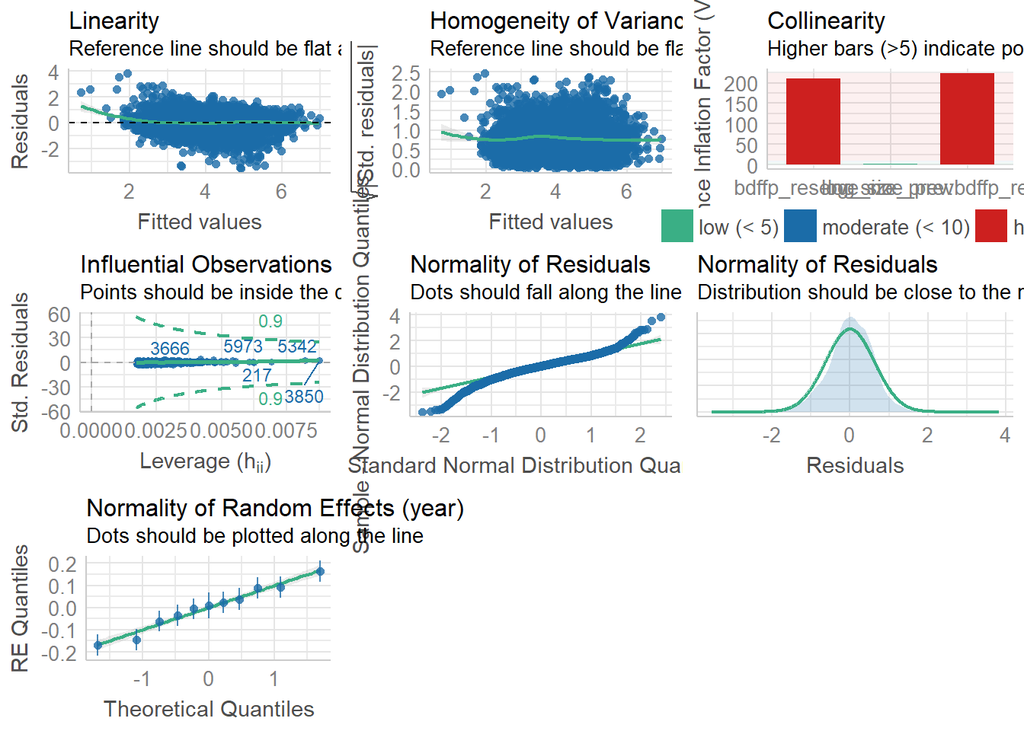

```r
performance::check_model(log_size.m3) # high collinearity
```

```r
log_size.m4 <- lmer(log_size~log_size_prev+bdffp_reserve_no+(1|year),data=dist_10m)

anova(log_size.m3,log_size.m4,test="LRT")
```

```
## refitting model(s) with ML (instead of REML)
```

```
## Data: dist_10m
## Models:
## log_size.m4: log_size ~ log_size_prev + bdffp_reserve_no + (1 | year)
## log_size.m3: log_size ~ log_size_prev * bdffp_reserve_no + (1 | year)
##             npar   AIC   BIC logLik deviance  Chisq Df Pr(>Chisq)
## log_size.m4    6 12938 12979  -6463    12926
## log_size.m3    8 12930 12984  -6457    12914 11.972  2   0.002514 **
## ---
## Signif. codes:  0 '***' 0.001 '**' 0.01 '*' 0.05 '.' 0.1 ' ' 1
```

```r
check_outliers(log_size.m4)
```

```
## OK: No outliers detected.
```

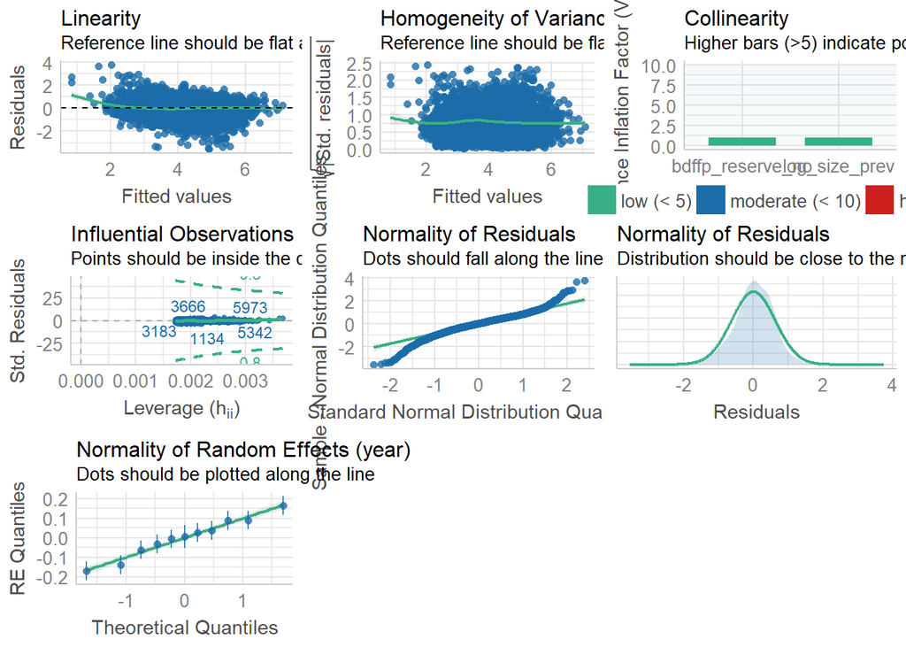

```r
performance::check_model(log_size.m4)
```

```r
tab_model(log_size.m4)
```

|  | log_size |  |  |
| --- | --- | --- | --- |
| Predictors | Estimates | CI | p |
| (Intercept) | 0.78 | 0.69 – 0.86 | **<0.001** |
| log_size_prev | 0.83 | 0.81 – 0.84 | **<0.001** |
| bdffp_reserve_no [2107] | -0.01 | -0.05 – 0.02 | 0.449 |
| bdffp_reserve_no [3114] | -0.10 | -0.14 – -0.06 | **<0.001** |
| Random Effects |  |  |  |
| σ<sup>2</sup> | 0.40 |  |  |
| τ<sub>00</sub> <sub>year</sub> | 0.01 |  |  |
| ICC | 0.03 |  |  |
| N <sub>year</sub> | 11 |  |  |
| Observations | 6735 |  |  |
| Marginal R<sup>2</sup> / Conditional R<sup>2</sup> | 0.679 / 0.687 |  |  |

Repeating this analysis for finer distances, I still found that distance to nearest edge was not a significant predictor variable for log_size of *H. acuminata*, while year remained a significant random effect.

```
## refitting model(s) with ML (instead of REML)
```

```
## Data: dist_fine
## Models:
## log_size_fine.m2: log_size ~ log_size_prev * bdffp_reserve_no * distance_to_nearest_edge
## log_size_fine.m1: log_size ~ log_size_prev * bdffp_reserve_no * distance_to_nearest_edge + (1 | year)
##                  npar    AIC    BIC  logLik deviance  Chisq Df Pr(>Chisq)
## log_size_fine.m2   13 7877.0 7959.7 -3925.5   7851.0
## log_size_fine.m1   14 7769.2 7858.2 -3870.6   7741.2 109.79  1  < 2.2e-16 ***
## ---
## Signif. codes:  0 '***' 0.001 '**' 0.01 '*' 0.05 '.' 0.1 ' ' 1
```

```
## Analysis of Deviance Table (Type II Wald chisquare tests)
##
## Response: log_size
##                                                              Chisq Df
## log_size_prev                                           10017.8719  1
## bdffp_reserve_no                                           18.6398  2
## distance_to_nearest_edge                                    2.0108  1
## log_size_prev:bdffp_reserve_no                              2.4739  2
## log_size_prev:distance_to_nearest_edge                      0.1105  1
## bdffp_reserve_no:distance_to_nearest_edge                   4.0273  2
## log_size_prev:bdffp_reserve_no:distance_to_nearest_edge     0.7841  2
##                                                         Pr(>Chisq)
## log_size_prev                                            < 2.2e-16 ***
## bdffp_reserve_no                                         8.962e-05 ***
## distance_to_nearest_edge                                    0.1562
## log_size_prev:bdffp_reserve_no                              0.2903
## log_size_prev:distance_to_nearest_edge                      0.7396
## bdffp_reserve_no:distance_to_nearest_edge                   0.1335
## log_size_prev:bdffp_reserve_no:distance_to_nearest_edge     0.6757
## ---
## Signif. codes:  0 '***' 0.001 '**' 0.01 '*' 0.05 '.' 0.1 ' ' 1
```

```
## refitting model(s) with ML (instead of REML)
```

```
## Data: dist_fine
## Models:
## log_size_fine.m3: log_size ~ log_size_prev + bdffp_reserve_no + distance_to_nearest_edge + (1 | year)
## log_size_fine.m1: log_size ~ log_size_prev * bdffp_reserve_no * distance_to_nearest_edge + (1 | year)
##                  npar    AIC    BIC  logLik deviance  Chisq Df Pr(>Chisq)
## log_size_fine.m3    7 7762.5 7807.0 -3874.2   7748.5
## log_size_fine.m1   14 7769.2 7858.2 -3870.6   7741.2 7.2957  7     0.3987
```

```
## Linear mixed model fit by REML ['lmerMod']
## Formula: log_size ~ log_size_prev + bdffp_reserve_no + (1 | year)
##    Data: dist_fine
##
## REML criterion at convergence: 7775.1
##
## Scaled residuals:
##     Min      1Q  Median      3Q     Max
## -5.9522 -0.5222  0.0552  0.6281  6.1925
##
## Random effects:
##  Groups   Name        Variance Std.Dev.
##  year     (Intercept) 0.01249  0.1118
##  Residual             0.35611  0.5968
## Number of obs: 4279, groups:  year, 11
##
## Fixed effects:
##                       Estimate Std. Error t value
## (Intercept)           0.806352   0.051080  15.786
## log_size_prev         0.826851   0.008219 100.608
## bdffp_reserve_no2107 -0.006346   0.022014  -0.288
## bdffp_reserve_no3114 -0.091213   0.022789  -4.002
##
## Correlation of Fixed Effects:
##             (Intr) lg_sz_ b__210
## log_siz_prv -0.685
## bdffp__2107 -0.270  0.071
## bdffp__3114 -0.223  0.014  0.495
```

```
## refitting model(s) with ML (instead of REML)
```

```
## Data: dist_fine
## Models:
## log_size_fine.m4: log_size ~ log_size_prev + bdffp_reserve_no + (1 | year)
## log_size_fine.m3: log_size ~ log_size_prev + bdffp_reserve_no + distance_to_nearest_edge + (1 | year)
##                  npar    AIC    BIC  logLik deviance  Chisq Df Pr(>Chisq)
## log_size_fine.m4    6 7762.6 7800.7 -3875.3   7750.6
## log_size_fine.m3    7 7762.5 7807.0 -3874.2   7748.5 2.1124  1     0.1461
```

```
## refitting model(s) with ML (instead of REML)
```

```
## Data: dist_fine
## Models:
## log_size_fine.m5: log_size ~ log_size_prev + (1 | year)
## log_size_fine.m4: log_size ~ log_size_prev + bdffp_reserve_no + (1 | year)
##                  npar    AIC    BIC  logLik deviance  Chisq Df Pr(>Chisq)
## log_size_fine.m5    4 7778.4 7803.8 -3885.2   7770.4
## log_size_fine.m4    6 7762.6 7800.7 -3875.3   7750.6 19.784  2  5.058e-05 ***
## ---
## Signif. codes:  0 '***' 0.001 '**' 0.01 '*' 0.05 '.' 0.1 ' ' 1
```

```
## OK: No outliers detected.
```

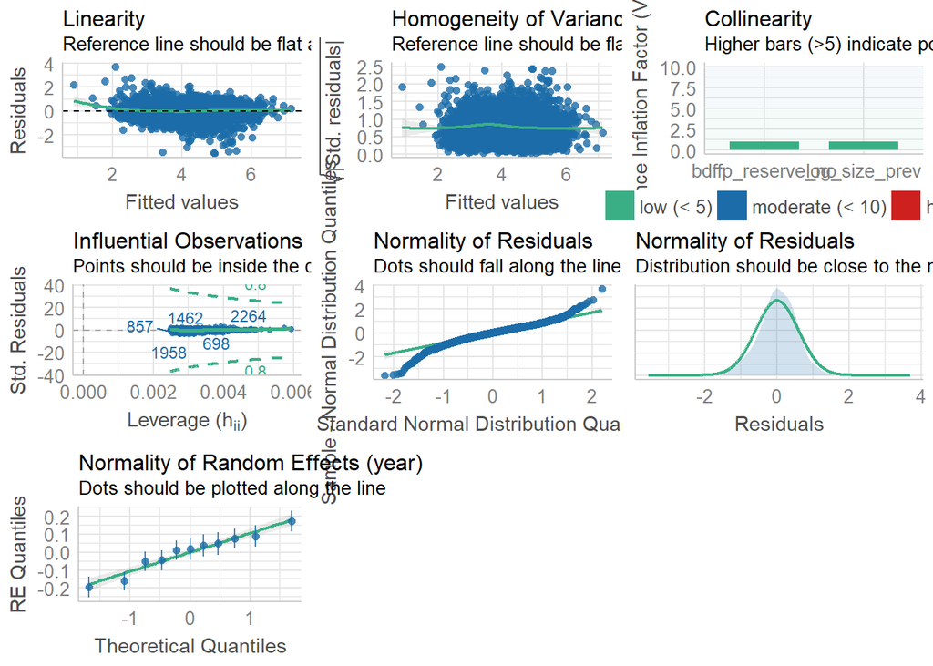

|  | log_size |  |  |
| --- | --- | --- | --- |
| Predictors | Estimates | CI | p |
| (Intercept) | 0.81 | 0.71 – 0.91 | **<0.001** |
| log_size_prev | 0.83 | 0.81 – 0.84 | **<0.001** |
| bdffp_reserve_no [2107] | -0.01 | -0.05 – 0.04 | 0.773 |
| bdffp_reserve_no [3114] | -0.09 | -0.14 – -0.05 | **<0.001** |
| Random Effects |  |  |  |
| σ<sup>2</sup> | 0.36 |  |  |
| τ<sub>00</sub> <sub>year</sub> | 0.01 |  |  |
| ICC | 0.03 |  |  |
| N <sub>year</sub> | 11 |  |  |
| Observations | 4279 |  |  |
| Marginal R<sup>2</sup> / Conditional R<sup>2</sup> | 0.698 / 0.708 |  |  |

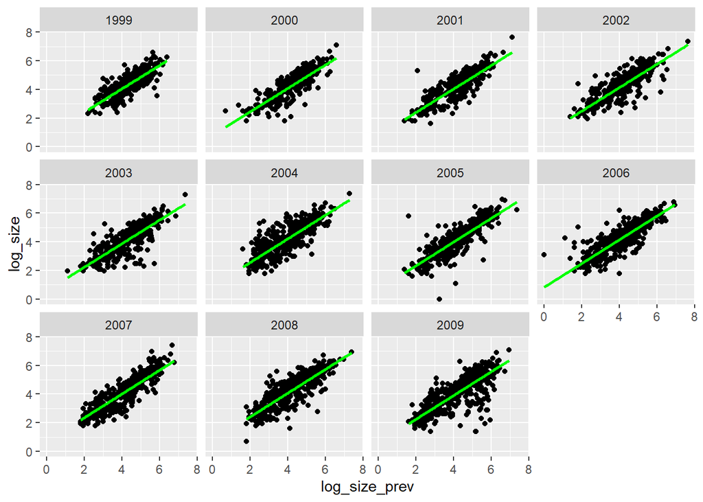

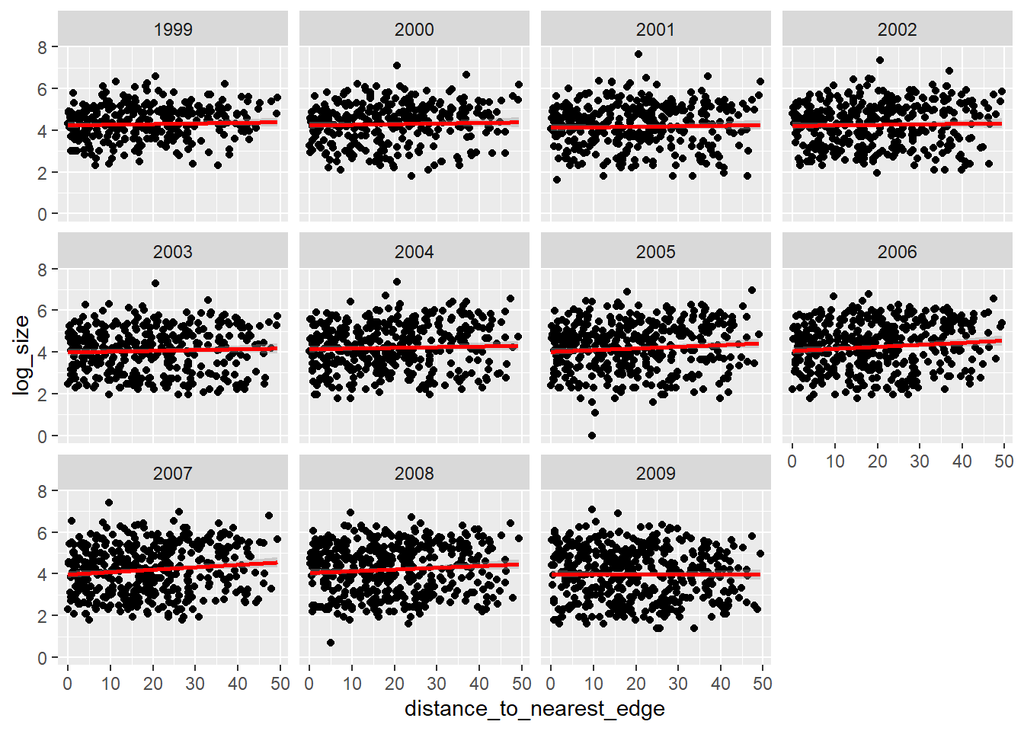